# TS HW 3

Anusha Bhat

2025-01-29

```r
library(tseries)
library(xts)
library(zoo)
library(forecast)
```

## Question 1: Dividing the Data

```r
# load data
busses = read.csv("C:\\Users\\anush\\Downloads\\average-monthly-ridership.csv")

# year-month format for date
busses$Month <- as.yearmon(busses$Month, format="%Y-%m")

# rename column for easy indexing
colnames(busses) <- c("Month", "Ridership")

head(busses)
```

```
##      Month Ridership
## 1 Jan 2010       648
## 2 Feb 2010       646
## 3 Mar 2010       639
## 4 Apr 2010       654
## 5 May 2010       630
## 6 Jun 2010       622
```

```r
# convert data into an XTS object
busses2 <- xts(busses$Ridership, order.by = busses$Month)

head(busses2)
```

```
##          [,1]
## Jan 2010  648
## Feb 2010  646
## Mar 2010  639
## Apr 2010  654
## May 2010  630
## Jun 2010  622
```

```r
# cut off dates for splitting train and test data
train_end_date <- as.yearmon("2018-12")
test_start_date <- as.yearmon("2019-01")
test_end_date <- as.yearmon("2019-06")
```

```r
# split train data
train_data <- busses2[index(busses2) <= train_end_date]

head(train_data)
```

```
##          [,1]
## Jan 2010  648
## Feb 2010  646
## Mar 2010  639
## Apr 2010  654
## May 2010  630
## Jun 2010  622
```

```r
tail(train_data)
```

```
##          [,1]
## Jul 2018 1258
## Aug 2018 1214
## Sep 2018 1326
## Oct 2018 1417
## Nov 2018 1417
## Dec 2018 1329
```

```r
# split test data
test_data <- busses2[index(busses2) >= test_start_date & index(busses2) <= test_end_date]

head(test_data)
```

```
##          [,1]
## Jan 2019 1461
## Feb 2019 1425
## Mar 2019 1419
## Apr 2019 1432
## May 2019 1394
## Jun 2019 1327
```

```r
tail(test_data)
```

```
##          [,1]
## Jan 2019 1461
## Feb 2019 1425
## Mar 2019 1419
## Apr 2019 1432
## May 2019 1394
## Jun 2019 1327
```

## Question 2: EDA of Train Data Qualitative Analysis

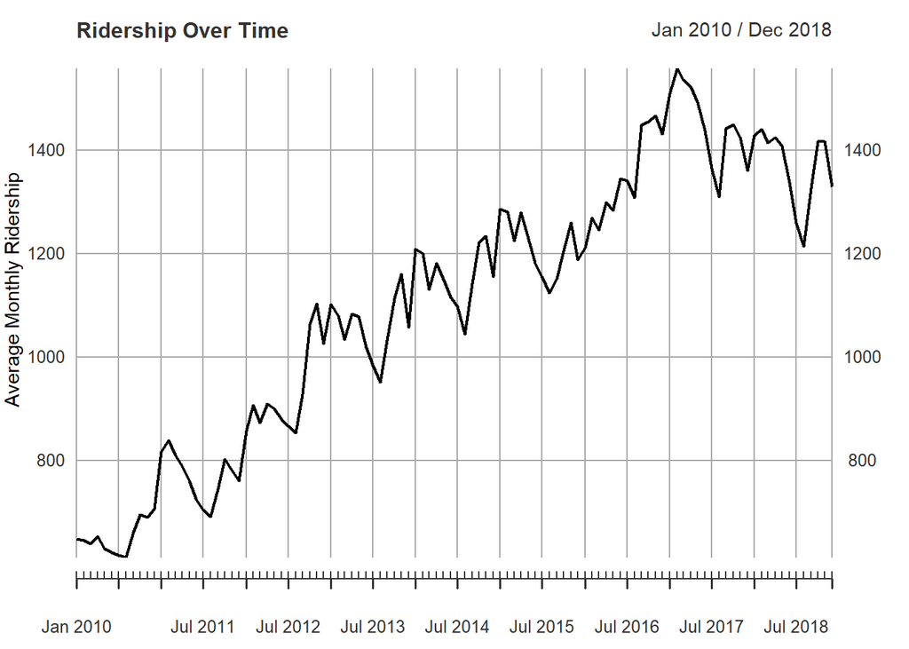

```r
plot(train_data, xlab = "Month",
     ylab = "Average Monthly Ridership",
     main = "Ridership Over Time")
```

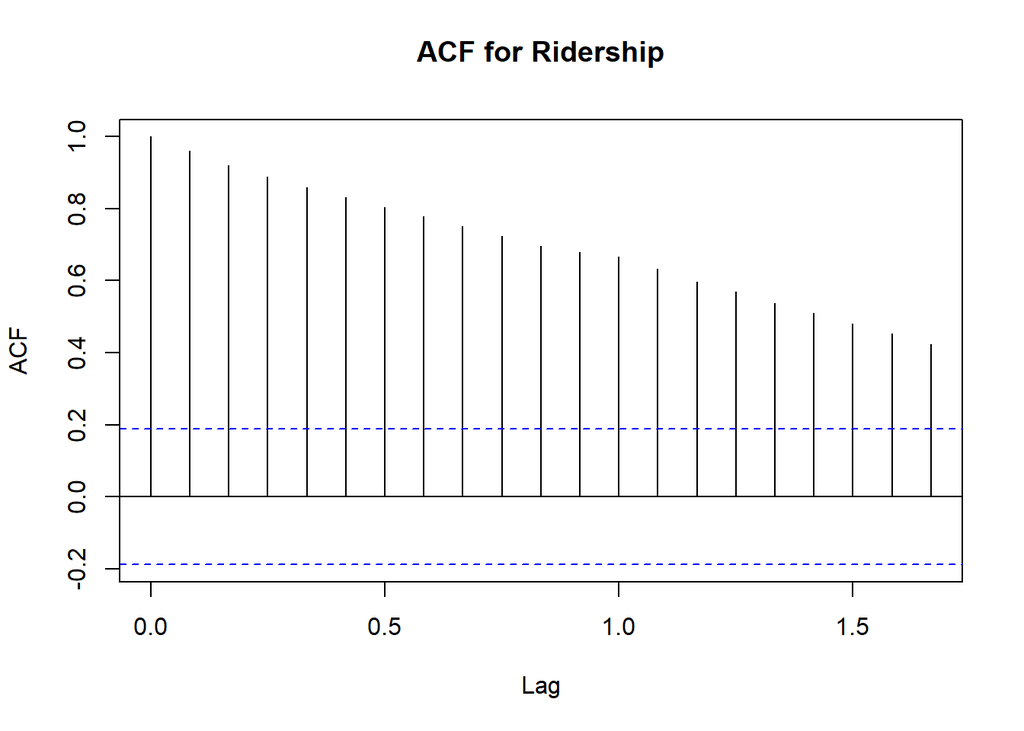

```r
acf(train_data, main = "ACF for Ridership")
```

The data plot has an upwards trend until January 2017 and then a downwards trend, indicating that the average monthly ridership is increasing until January 2017 and decreasing after. Moreover, there is a lack of a constant mean which the data points fluctuate around. Due to this trend, and the lack of a constant mean, the time series is not stationary. Additionally, the ACF plot also has a decreasing trend with the autocorrelations decaying as the lags increase, further indicating that the time series is not stationary.

## Question 3: EDA of Train Data Quantitative Analysis

```r
var = var(train_data)
cat("variance:", var)
```

```
## variance: 72449
```

```r
adf.test(train_data)
```

```
##
##  Augmented Dickey-Fuller Test
##
## data:  train_data
## Dickey-Fuller = -2.1874, Lag order = 4, p-value = 0.4989
## alternative hypothesis: stationary
```

```r
kpss.test(train_data)
```

```
##
##  KPSS Test for Level Stationarity
##
## data:  train_data
## KPSS Level = 2.0957, Truncation lag parameter = 4, p-value = 0.01
```

The ADF test results in a p-value greater than an alpha level of 0.05, so we fail to reject the null hypothesis that the time series is not stationary. Additionally, the KPSS test results in a p-value less than an alpha level of 0.05, so we reject the null hypothesis that the time series is stationary. Lastly, the variance of the time series is high, reflecting large fluctuations over time. This further indicates that the time series is not stationary, in support with our previous qualitative analysis using the data plot and ACF plot in question 2.

# Question 4 & 5: Auto Arima Model

```r
aa = auto.arima(ts(train_data[,1]))
aa
```

```
## Series: ts(train_data[, 1])
## ARIMA(0,1,2) with drift
##
## Coefficients:
##           ma1      ma2   drift
##       -0.0447  -0.3104  6.6540
## s.e.   0.0966   0.1053  3.3997
##
## sigma^2 = 2997:  log likelihood = -578.7
## AIC=1165.4   AICc=1165.8   BIC=1176.09
```

In this model, p = 0, d = 1, q = 2. Since d = 1, this indicates that the model differenced the time series once in order to make it stationary. This means that the original time series was not stationary, supporting our EDA analysis in questions 2 and 3 that the time series is not stationary.

## Question 6: Plot Forecast

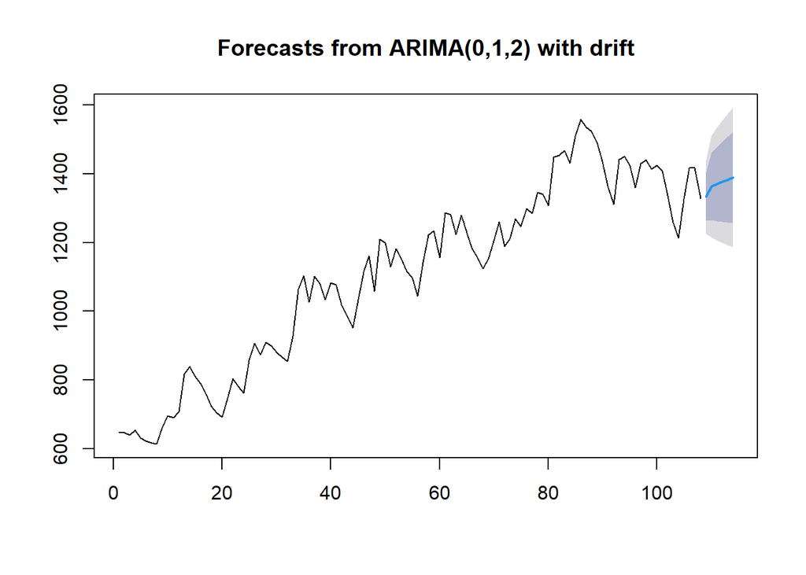

```r
plot(forecast(aa,h=6))
```

## Question 7: Forecast Accuracy

```r
accuracy(forecast(aa, h=6), test_data)
```

```
##                      ME     RMSE      MAE        MPE     MAPE     MASE
## Training set -0.1159702 53.72452 43.90696 -0.0956003 3.995772 0.973688
## Test set     40.5110043 70.39017 61.39005  2.7540905 4.327492 1.361396
##                    ACF1
## Training set 0.01033776
## Test set             NA
```

## Question 8: Arima Models

```r
# p = 0, d = 1, q = 3
mod2 = arima(ts(train_data[,1]),
             order=c(0,1,3))

# p = 1, d = 2, q = 2
mod3 = arima(ts(train_data[,1]),
             order=c(1,2,2))
```

```r
print("Model 2 Arima")
```

```
## [1] "Model 2 Arima"
```

```r
mod2
```

```
##
## Call:
## arima(x = ts(train_data[, 1]), order = c(0, 1, 3))
##
## Coefficients:
##           ma1      ma2     ma3
##       -0.0004  -0.2574  0.0122
## s.e.   0.0965   0.0991  0.1019
##
## sigma^2 estimated as 3003:  log likelihood = -580.3,  aic = 1168.59
```

```r
print("Model 3 Arima")
```

```
## [1] "Model 3 Arima"
```

```r
mod2
```

[output not shown]

## Question 9: Forecast Plots

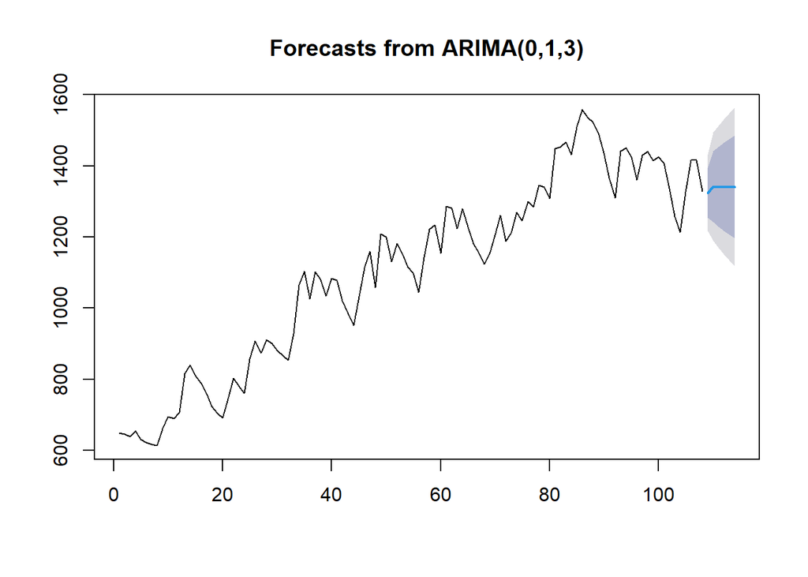

```r
# forecast for model 2
plot(forecast(mod2,h=6))
```

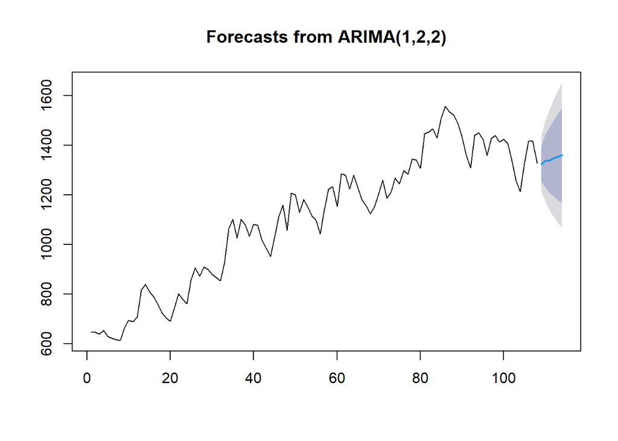

```r
# forecast for model 3
plot(forecast(mod3,h=6))
```

## Question 10: Forecast Accuracies

```r
print("Model 1")
```

```
## [1] "Model 1"
```

```r
accuracy(forecast(aa, h=6), test_data)
```

```
##                      ME     RMSE      MAE        MPE     MAPE     MASE
## Training set -0.1159702 53.72452 43.90696 -0.0956003 3.995772 0.973688
## Test set     40.5110043 70.39017 61.39005  2.7540905 4.327492 1.361396
##                    ACF1
## Training set 0.01033776
## Test set             NA
```

```r
print("Model 2")
```

```
## [1] "Model 2"
```

```r
accuracy(forecast(mod2, h=6), test_data)
```

```
##                     ME     RMSE      MAE      MPE     MAPE     MASE       ACF1
## Training set  8.517137 54.54934 42.98606 0.739178 3.880084 0.953266 -0.0275625
## Test set     71.367380 84.75928 76.04967 4.968966 5.321814 1.686490         NA
```

```r
print("Model 3")
```

```
## [1] "Model 3"
```

```r
accuracy(forecast(mod3, h=6), test_data)
```

```
##                     ME     RMSE      MAE        MPE     MAPE      MASE
## Training set -1.382852 55.41144 45.05435 -0.1347907 4.055315 0.9991327
## Test set     65.149032 83.55324 76.47780  4.5129909 5.366703 1.6959843
##                     ACF1
## Training set -0.09950291
## Test set              NA
```

Model 1 has the best test RMSE, with a value of approximately 70.39. Model 1 also has the lowest train ACF, with a value of approximately 0.01 (this is the model with the ACF closest to 0).